# Ekonometria Przestrzenna

Zadanie 3 - Testowanie obecności procesów przestrzennych

Globalny test Morana

```r
model.liniowy <- lm(spatial_data$Mean ~ spatial_data$PKB)
res <- model.liniowy$residuals
cont1 <- poly2nb(spatial_data, queen = T)
W1_list <- nb2listw(cont1, style = "W", zero.policy = TRUE)
moran.test(spatial_data$Mean, listw = W1_list,alternative = "greater")
```

```
    Moran I test under randomisation

data:  spatial_data$Mean
weights: W1_list

Moran I statistic standard deviate = 9.3274, p-value < 2.2e-16
alternative hypothesis: greater
sample estimates:
Moran I statistic       Expectation          Variance
      0.328833956      -0.007352941       0.001299084
```

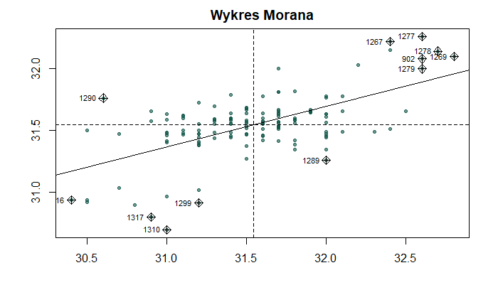

```r
moran.plot(spatial_data$Mean, listw = W1_list, ylab="", xlab="", pch = 20, main = "Wykres Morana", col = sgh_green)
```

Lokalny Test Morana

```r
head(localmoran(spatial_data$Mean, W1_list, p.adjust.method = "bonferroni"),20)
```

```
               Ii         E.Ii     Var.Ii        Z.Ii    Pr(z > 0)
902   1.800574347 -0.005093312 0.09165816  5.96420074 7.375031e-09
916   1.807697249 -0.005579444 0.09097031  6.01193467 6.416277e-09
1014 -0.009934842 -0.022433714 0.02837557  0.07419908 1.000000e+00
1016  0.020312994 -0.010923938 0.07927678  0.11094184 1.000000e+00
1017  0.234226414 -0.005579444 0.09097031  0.79507841 1.000000e+00
1018  0.178493273 -0.008212719 0.08615533  0.63608799 1.000000e+00
1019  0.017660943 -0.006026488 0.09028245  0.07883450 1.000000e+00
1020  0.017660943 -0.006026488 0.09028245  0.07883450 1.000000e+00
1021  0.114550663 -0.005579444 0.09097031  0.39829242 1.000000e+00
1022  0.028896292 -0.006833396 0.08890674  0.11982898 1.000000e+00
1023 -0.187039909 -0.007554603 0.08753103 -0.60666350 1.000000e+00
1024  0.010018735 -0.007203031 0.08821889  0.05798249 1.000000e+00
1025 -0.054962029 -0.012476016 0.07446180 -0.15569663 1.000000e+00
1026  0.061593975 -0.006833396 0.08890674  0.22948933 1.000000e+00
1027 -0.045198588 -0.014406063 0.06758326 -0.11844746 1.000000e+00
1028 -0.114398203 -0.009391604 0.08340391 -0.36359960 1.000000e+00
1029  0.154813696 -0.006026488 0.09028245  0.53529463 1.000000e+00
1030  0.109793110 -0.004555597 0.09234601  0.37628957 1.000000e+00
1031 -0.059207177 -0.007890525 0.08684318 -0.17413676 1.000000e+00
1032 -0.020453017 -0.005579444 0.09097031 -0.04931346 1.000000e+00
```

Autokorelacja reszt

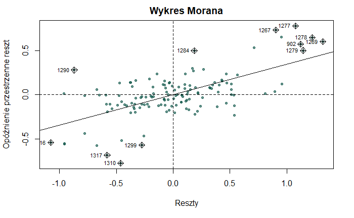

```r
moran.plot(res, W1_list, ylab="Opóźnienie przestrzenne reszt", xlab="Reszty", pch = 20, main = "Wykres Morana", col = sgh_green)
```

```r
lm.morantest(model.liniowy, W1_list, alternative = "greater")
```

```
    Global Moran I for regression residuals

data:
model: lm(formula = spatial_data$Mean ~ spatial_data$PKB)
weights: W1_list

Moran I statistic standard deviate = 10.196, p-value < 2.2e-16
alternative hypothesis: greater
sample estimates:
Observed Moran I      Expectation         Variance
     0.343564957     -0.012100875      0.001216782
```

Geary’s C test

```r
geary.test(spatial_data$Mean, W1_list)
```

```
    Geary C test under randomisation

data:  spatial_data$Mean
weights: W1_list

Geary C statistic standard deviate = 5.293, p-value = 6.016e-08
alternative hypothesis: Expectation greater than statistic
sample estimates:
Geary C statistic       Expectation          Variance
      0.577518546       1.000000000       0.006371069
```

Podzielenie wartości zmiennej na dwie klasy

```r
joincount.test(as.factor(spatial_data$Mean > 31.45), listw = W1_list)
```

```
    Join count test under nonfree sampling

data:  as.factor(spatial_data$Mean > 31.45)
weights: W1_list

Std. deviate for FALSE = 0.81632, p-value = 0.2072
alternative hypothesis: greater
sample estimates:
Same colour statistic           Expectation              Variance
            12.501351             11.323529              2.081772


    Join count test under nonfree sampling

data:  as.factor(spatial_data$Mean > 31.45)
weights: W1_list

Std. deviate for TRUE = 2.5458, p-value = 0.005451
alternative hypothesis: greater
sample estimates:
Same colour statistic           Expectation              Variance
            28.916068             23.823529              4.001332
```

```r
joincount.test(as.factor(spatial_data$Mean > 31.5), listw = W1_list)
```

```
    Join count test under nonfree sampling

data:  as.factor(spatial_data$Mean > 31.5)
weights: W1_list

Std. deviate for FALSE = 2.2044, p-value = 0.01375
alternative hypothesis: greater
sample estimates:
Same colour statistic           Expectation              Variance
            21.135775             17.250000              3.107339


    Join count test under nonfree sampling

data:  as.factor(spatial_data$Mean > 31.5)
weights: W1_list

Std. deviate for TRUE = 0.74771, p-value = 0.2273
alternative hypothesis: greater
sample estimates:
Same colour statistic           Expectation              Variance
            18.051083             16.750000              3.027916
```

```r
joincount.test(as.factor(spatial_data$Mean > 31.55), listw = W1_list)
```

```
    Join count test under nonfree sampling

data:  as.factor(spatial_data$Mean > 31.55)
weights: W1_list

Std. deviate for FALSE = 2.2044, p-value = 0.01375
alternative hypothesis: greater
sample estimates:
Same colour statistic           Expectation              Variance
            21.135775             17.250000              3.107339


    Join count test under nonfree sampling

data:  as.factor(spatial_data$Mean > 31.55)
weights: W1_list

Std. deviate for TRUE = 0.74771, p-value = 0.2273
alternative hypothesis: greater
sample estimates:
Same colour statistic           Expectation              Variance
            18.051083             16.750000              3.027916
```

Morana i Gearyego wskazuje na istnienie dodatniej korelacji zmiennej. Występuje dodatnia autokorelacja reszt, zatem wykorzystanie modeli przestrzennych jest zasadne. Wybrałem 31,5 czyli mediane żeby podzielić z podobna liczebnością

Zadanie 5 - Proste Modele regresji przestrzennej

Model czystej autoregresjii przestrzennej

```r
model_pure_sar <- spautolm(spatial_data$Mean ~ 1, listw = W1_list)
summary(model_pure_sar)
```

```
Call: spautolm(formula = spatial_data$Mean ~ 1, listw = W1_list)

Residuals:
      Min        1Q    Median        3Q       Max
-1.118373 -0.229900  0.018169  0.260526  0.883615

Coefficients:
            Estimate Std. Error z value  Pr(>|z|)
(Intercept) 31.52075    0.17343  181.75 < 2.2e-16

Lambda: 0.81364 LR test value: 46.695 p-value: 8.2928e-12
Numerical Hessian standard error of lambda: 0.087946

Log likelihood: -67.08523
ML residual variance (sigma squared): 0.14311, (sigma: 0.3783)
Number of observations: 137
Number of parameters estimated: 3
AIC: 140.17
```

```r
res_pure_sar <- model_pure_sar$fit$residuals
moran.test(res_pure_sar, W1_list)
```

```
    Moran I test under randomisation

data:  res_pure_sar
weights: W1_list

Moran I statistic standard deviate = 0.10131, p-value = 0.4597
alternative hypothesis: greater
sample estimates:
Moran I statistic       Expectation          Variance
     -0.003699550      -0.007352941       0.001300548
```

SAR

```r
model_sar <- lagsarlm(spatial_data$Mean ~ spatial_data$PKB, listw = W1_list)
summary(model_sar)
```

```
Call:lagsarlm(formula = spatial_data$Mean ~ spatial_data$PKB, listw = W1_list)

Residuals:
        Min          1Q      Median          3Q         Max
-1.0589e+00 -2.5584e-01 -9.1879e-05  2.4432e-01  9.1503e-01

Type: lag
Coefficients: (asymptotic standard errors)
                  Estimate Std. Error z value Pr(>|z|)
(Intercept)      5.7624745  2.2821555   2.525  0.01157
spatial_data$PKB 0.0072324  0.0048769   1.483  0.13808

Rho: 0.81151, LR test value: 46.771, p-value: 7.9772e-12
Asymptotic standard error: 0.073211
    z-value: 11.084, p-value: < 2.22e-16
Wald statistic: 122.87, p-value: < 2.22e-16

Log likelihood: -65.91783 for lag model
ML residual variance (sigma squared): 0.14078, (sigma: 0.37521)
Number of observations: 137
Number of parameters estimated: 4
AIC: 139.84, (AIC for lm: 184.61)
LM test for residual autocorrelation
test value: 0.30789, p-value: 0.57898
```

```r
res_sar <- model_sar$residuals
moran.test(res_sar, listw = W1_list)
```

```
    Moran I test under randomisation

data:  res_sar
weights: W1_list

Moran I statistic standard deviate = 0.51239, p-value = 0.3042
alternative hypothesis: greater
sample estimates:
Moran I statistic       Expectation          Variance
      0.011122813      -0.007352941       0.001300155
```

```r
colors <- brewer.pal(6, "BuGn")
brks <- classIntervals(res_sar, n = 6, style = "quantile")
brks <- brks$brks
plot(spatial_data, col = colors[findInterval(res_sar, brks, all.inside = TRUE)], axes = F)
title(paste ("Reszty z modelu SAR"),sub = "source: Eurostat")
```

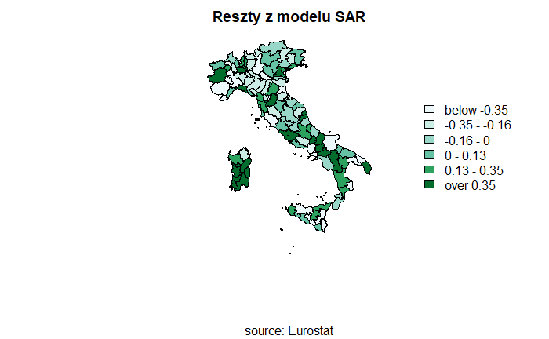

```r
legend(x = "right", legend = leglabs(round(brks, 2), under = "below", over = "over"), fill = colors, bty = "n", x.intersp = 1, y.intersp = 1)
```

SLX

```r
W <- listw2mat(W1_list)
X <- cbind(spatial_data$PKB)
WX <- W %*% X
lag.PKB <- WX [, 1]
model_slx <- lm(spatial_data$Mean ~ spatial_data$PKB + lag.PKB)
summary(model_slx)
```

```
Call:
lm(formula = spatial_data$Mean ~ spatial_data$PKB + lag.PKB)

Residuals:
     Min       1Q   Median       3Q      Max
-1.18662 -0.24474 -0.00727  0.23293  1.27775

Coefficients:
                  Estimate Std. Error t value Pr(>|t|)
(Intercept)      31.660224   0.194180 163.046  < 2e-16 ***
spatial_data$PKB  0.030534   0.009976   3.061  0.00267 **
lag.PKB          -0.034299   0.012870  -2.665  0.00864 **
---
Signif. codes:  0 ‘***’ 0.001 ‘**’ 0.01 ‘*’ 0.05 ‘.’ 0.1 ‘ ’ 1

Residual standard error: 0.4576 on 134 degrees of freedom
Multiple R-squared:  0.06586,   Adjusted R-squared:  0.05192
F-statistic: 4.724 on 2 and 134 DF,  p-value: 0.01041
```

```r
print(paste("AIC:",as.character(AIC(model_slx))))
```

```
[1] "AIC: 179.531458951672"
```

```r
res_slx <- model_slx$residuals
lm.morantest(model_slx, listw = W1_list)
```

```
    Global Moran I for regression residuals

data:
model: lm(formula = spatial_data$Mean ~ spatial_data$PKB + lag.PKB)
weights: W1_list

Moran I statistic standard deviate = 10.395, p-value < 2.2e-16
alternative hypothesis: greater
sample estimates:
Observed Moran I      Expectation         Variance
     0.349378081     -0.013076471      0.001215722
```

```r
colors <- brewer.pal(6, "BuGn")
brks <- classIntervals(res_slx, n = 6, style = "quantile")
brks <- brks$brks
plot(spatial_data, col = colors[findInterval(res_slx, brks, all.inside = TRUE)], axes = F)
title(paste ("Reszty z modelu SLX"),sub = "source: Eurostat")
```

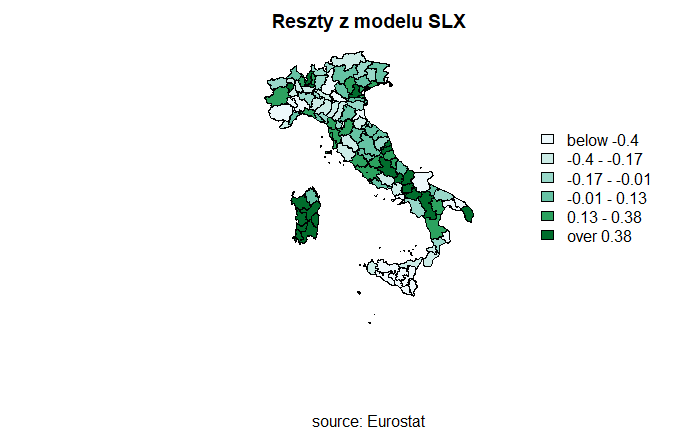

```r
legend(x = "right", legend = leglabs(round(brks, 2), under = "below", over = "over"), fill = colors, bty = "n", x.intersp = 1, y.intersp = 1)
```

SEM

```r
model_sem <- errorsarlm(spatial_data$Mean ~ spatial_data$PKB, listw = W1_list)
summary(model_sem)
```

```
Call:errorsarlm(formula = spatial_data$Mean ~ spatial_data$PKB, listw = W1_list)

Residuals:
        Min          1Q      Median          3Q         Max
-1.07910628 -0.21608766 -0.00078768  0.22259023  0.82580507

Type: error
Coefficients: (asymptotic standard errors)
                   Estimate Std. Error  z value  Pr(>|z|)
(Intercept)      30.9623122  0.2919607 106.0496 < 2.2e-16
spatial_data$PKB  0.0281169  0.0075842   3.7073 0.0002095

Lambda: 0.87897, LR test value: 56.916, p-value: 4.5519e-14
Asymptotic standard error: 0.054758
    z-value: 16.052, p-value: < 2.22e-16
Wald statistic: 257.67, p-value: < 2.22e-16

Log likelihood: -60.84544 for error model
ML residual variance (sigma squared): 0.12775, (sigma: 0.35743)
Number of observations: 137
Number of parameters estimated: 4
AIC: 129.69, (AIC for lm: 184.61)
```

```r
res_sem <- model_sem$residuals
moran.test(res_sem, listw = W1_list)
```

```
    Moran I test under randomisation

data:  res_sem
weights: W1_list

Moran I statistic standard deviate = -0.19037, p-value = 0.5755
alternative hypothesis: greater
sample estimates:
Moran I statistic       Expectation          Variance
     -0.014210935      -0.007352941       0.001297765
```

```r
colors <- brewer.pal(6, "BuGn")
brks <- classIntervals(res_slx, n = 6, style = "quantile")
brks <- brks$brks
plot(spatial_data, col = colors[findInterval(res_slx, brks, all.inside = TRUE)], axes = F)
title(paste ("Reszty z modelu SEM "),sub = "source: Eurostat")
```

[figure not shown]

```r
legend(x = "right", legend = leglabs(round(brks, 2), under = "below", over = "over"), fill = colors, bty = "n", x.intersp = 1, y.intersp = 1)
```

Testy LR

```r
#1
lL0 <- logLik(model_sar)
lL1 <- logLik(model_slx)
LRa <- 2 * (lL1 - lL0)
print(LR.p.value <- pchisq(as.numeric(LRa), df = 2, lower.tail = FALSE))
```

```
[1] 1
```

```r
#2
lL0 <- logLik(model_sar)
lL1 <- logLik(model_sem)
LRa <- 2 * (lL1 - lL0)
print(LR.p.value <- pchisq(as.numeric(LRa), df = 2, lower.tail = FALSE))
```

```
[1] 0.006267466
```

```r
#3
lL0 <- logLik(model_sem)
lL1 <- logLik(model_slx)
LRa <- 2 * (lL1 - lL0)
print(LR.p.value <- pchisq(as.numeric(LRa), df = 2, lower.tail = FALSE))
```

```
[1] 1
```

Zadanie 6 - złożone modele regresji przestrzennej

Model SARAR

```r
model_sarar <- sacsarlm(spatial_data$Mean ~ spatial_data$PKB, listw = W1_list)
summary(model_sarar)
```

```
Call:sacsarlm(formula = spatial_data$Mean ~ spatial_data$PKB, listw = W1_list)

Residuals:
      Min        1Q    Median        3Q       Max
-1.040809 -0.213910 -0.010244  0.205895  0.827549

Type: sac
Coefficients: (asymptotic standard errors)
                   Estimate Std. Error z value  Pr(>|z|)
(Intercept)      39.2068037  8.2933569  4.7275 2.273e-06
spatial_data$PKB  0.0289303  0.0075739  3.8197 0.0001336

Rho: -0.25853
Asymptotic standard error: 0.26024
    z-value: -0.99343, p-value: 0.3205
Lambda: 0.93029
Asymptotic standard error: 0.046456
    z-value: 20.025, p-value: < 2.22e-16

LR test value: 57.915, p-value: 2.6534e-13

Log likelihood: -60.34587 for sac model
ML residual variance (sigma squared): 0.1232, (sigma: 0.35101)
Number of observations: 137
Number of parameters estimated: 5
AIC: 130.69, (AIC for lm: 184.61)
```

```r
res_sarar <- model_sarar$residuals
moran.test(res_sarar, listw = W1_list)
```

```
    Moran I test under randomisation

data:  res_sarar
weights: W1_list

Moran I statistic standard deviate = 0.51667, p-value = 0.3027
alternative hypothesis: greater
sample estimates:
Moran I statistic       Expectation          Variance
      0.011262188      -0.007352941       0.001298094
```

Model SDM

```r
model_sdm <- lagsarlm(spatial_data$Mean ~ spatial_data$PKB, listw = W1_list, type = "Durbin")
summary(model_sdm)
```

```
Call:lagsarlm(formula = spatial_data$Mean ~ spatial_data$PKB, listw = W1_list,     type = "Durbin")

Residuals:
       Min         1Q     Median         3Q        Max
-1.1393528 -0.1895538  0.0013842  0.2067743  0.8134948

Type: mixed
Coefficients: (asymptotic standard errors)
                       Estimate Std. Error z value  Pr(>|z|)
(Intercept)           5.2848761  2.1355798  2.4747 0.0133356
spatial_data$PKB      0.0313030  0.0077533  4.0374 5.405e-05
lag.spatial_data$PKB -0.0380716  0.0100063 -3.8048 0.0001419

Rho: 0.83853, LR test value: 53.384, p-value: 2.7434e-13
Asymptotic standard error: 0.066754
    z-value: 12.561, p-value: < 2.22e-16
Wald statistic: 157.79, p-value: < 2.22e-16

Log likelihood: -59.0738 for mixed model
ML residual variance (sigma squared): 0.12632, (sigma: 0.35541)
Number of observations: 137
Number of parameters estimated: 5
AIC: 128.15, (AIC for lm: 179.53)
LM test for residual autocorrelation
test value: 0.075222, p-value: 0.78388
```

```r
res_sdm <- model_sdm$residuals
moran.test(res_sdm, listw = W1_list)
```

```
    Moran I test under randomisation

data:  res_sdm
weights: W1_list

Moran I statistic standard deviate = 0.045352, p-value = 0.4819
alternative hypothesis: greater
sample estimates:
Moran I statistic       Expectation          Variance
     -0.005719769      -0.007352941       0.001296780
```

Model SDEM

```r
model_sdem <- errorsarlm(spatial_data$Mean ~ spatial_data$PKB, listw = W1_list, etype = "emixed")
summary(model_sdem)
```

```
Call:errorsarlm(formula = spatial_data$Mean ~ spatial_data$PKB, listw = W1_list,     etype = "emixed")

Residuals:
       Min         1Q     Median         3Q        Max
-1.1226023 -0.2094825  0.0065347  0.2022674  0.8341888

Type: error
Coefficients: (asymptotic standard errors)
                      Estimate Std. Error z value  Pr(>|z|)
(Intercept)          31.736050   0.547488 57.9667 < 2.2e-16
spatial_data$PKB      0.027310   0.007476  3.6530 0.0002592
lag.spatial_data$PKB -0.030539   0.019115 -1.5976 0.1101309

Lambda: 0.83437, LR test value: 52.021, p-value: 5.4912e-13
Asymptotic standard error: 0.068165
    z-value: 12.241, p-value: < 2.22e-16
Wald statistic: 149.83, p-value: < 2.22e-16

Log likelihood: -59.75535 for error model
ML residual variance (sigma squared): 0.12776, (sigma: 0.35743)
Number of observations: 137
Number of parameters estimated: 5
AIC: 129.51, (AIC for lm: 179.53)
```

```r
res_sdem <- model_sdem$residuals
moran.test(res_sdem, listw = W1_list)
```

```
    Moran I test under randomisation

data:  res_sdem
weights: W1_list

Moran I statistic standard deviate = 0.077619, p-value = 0.4691
alternative hypothesis: greater
sample estimates:
Moran I statistic       Expectation          Variance
     -0.004557675      -0.007352941       0.001296923
```

SAR VS SARAR

```r
lL0 <- logLik(model_sar)
lL1 <- logLik(model_sarar)
LRa <- 2 * (lL1 - lL0)
print(LR.p.value <- pchisq(as.numeric(LRa), df = 2, lower.tail = FALSE))
```

```
[1] 0.003803029
```

SAR VS SDM

```r
lL0 <- logLik(model_sar)
lL1 <- logLik(model_sdm)
LRa <- 2 * (lL1 - lL0)
print(LR.p.value <- pchisq(as.numeric(LRa), df = 2, lower.tail = FALSE))
```

```
[1] 0.001065801
```

SAR vs SDEM

```r
lL0 <- logLik(model_sar)
lL1 <- logLik(model_sdem)
LRa <- 2 * (lL1 - lL0)
print(LR.p.value <- pchisq(as.numeric(LRa), df = 2, lower.tail = FALSE))
```

```
[1] 0.002107034
```

SLX vs SARAR

```r
lL0 <- logLik(model_slx)
lL1 <- logLik(model_sarar)
LRa <- 2 * (lL1 - lL0)
print(LR.p.value <- pchisq(as.numeric(LRa), df = 2, lower.tail = FALSE))
```

```
[1] 9.126297e-12
```

SLX vs SDM

```r
lL0 <- logLik(model_slx)
lL1 <- logLik(model_sdm)
LRa <- 2 * (lL1 - lL0)
print(LR.p.value <- pchisq(as.numeric(LRa), df = 2, lower.tail = FALSE))
```

```
[1] 2.55765e-12
```

```r
lL0 <- logLik(model_sar)
lL1 <- logLik(model_sdem)
LRa <- 2 * (lL1 - lL0)
print(LR.p.value <- pchisq(as.numeric(LRa), df = 2, lower.tail = FALSE))
```

```
[1] 0.002107034
```

SEM vs SARAR

```r
lL0 <- logLik(model_sem)
lL1 <- logLik(model_sarar)
LRa <- 2 * (lL1 - lL0)
print(LR.p.value <- pchisq(as.numeric(LRa), df = 2, lower.tail = FALSE))
```

```
[1] 0.6067889
```

SEM vs SDM

```r
lL0 <- logLik(model_sem)
lL1 <- logLik(model_sdm)
LRa <- 2 * (lL1 - lL0)
print(LR.p.value <- pchisq(as.numeric(LRa), df = 2, lower.tail = FALSE))
```

```
[1] 0.1700529
```

SEM vs SDEM

```r
lL0 <- logLik(model_sem)
lL1 <- logLik(model_sdem)
LRa <- 2 * (lL1 - lL0)
print(LR.p.value <- pchisq(as.numeric(LRa), df = 2, lower.tail = FALSE))
```

```
[1] 0.336186
```

Z dwoma źródłami

SARAR vs SDM

```r
lL0 <- logLik(model_sarar)
lL1 <- logLik(model_sdm)
LRa <- 2 * (lL1 - lL0)
print(LR.p.value <- pchisq(as.numeric(LRa), df = 2, lower.tail = FALSE))
```

```
[1] 0.2802506
```

SARAR vs SDEM

```r
lL0 <- logLik(model_sarar)
lL1 <- logLik(model_sdem)
LRa <- 2 * (lL1 - lL0)
print(LR.p.value <- pchisq(as.numeric(LRa), df = 2, lower.tail = FALSE))
```

```
[1] 0.5540411
```

SDM vs SDEM

```r
lL0 <- logLik(model_sdm)
lL1 <- logLik(model_sdem)
LRa <- 2 * (lL1 - lL0)
print(LR.p.value <- pchisq(as.numeric(LRa), df = 2, lower.tail = FALSE))
```

```
[1] 1
```

```r
summary(model_sdm)
```

```
Call:lagsarlm(formula = spatial_data$Mean ~ spatial_data$PKB, listw = W1_list,     type = "Durbin")

Residuals:
       Min         1Q     Median         3Q        Max
-1.1393528 -0.1895538  0.0013842  0.2067743  0.8134948

Type: mixed
Coefficients: (asymptotic standard errors)
                       Estimate Std. Error z value  Pr(>|z|)
(Intercept)           5.2848761  2.1355798  2.4747 0.0133356
spatial_data$PKB      0.0313030  0.0077533  4.0374 5.405e-05
lag.spatial_data$PKB -0.0380716  0.0100063 -3.8048 0.0001419

Rho: 0.83853, LR test value: 53.384, p-value: 2.7434e-13
Asymptotic standard error: 0.066754
    z-value: 12.561, p-value: < 2.22e-16
Wald statistic: 157.79, p-value: < 2.22e-16

Log likelihood: -59.0738 for mixed model
ML residual variance (sigma squared): 0.12632, (sigma: 0.35541)
Number of observations: 137
Number of parameters estimated: 5
AIC: 128.15, (AIC for lm: 179.53)
LM test for residual autocorrelation
test value: 0.075222, p-value: 0.78388
```

Zadanie 8 Efekty

```r
SDM <- lagsarlm(spatial_data$Mean ~ spatial_data$PKB , listw = W1_list, type = "Durbin", control = list(fdHess = TRUE))
impacts.SDM <- impacts(SDM, listw = W1_list, zstats = TRUE, R = 200)
HPDinterval.lagImpact(impacts.SDM, prob = 0.95, choice = "direct")
```

```
                      lower      upper
spatial_data$PKB 0.01476013 0.04405515
attr(,"Probability")
[1] 0.9497487
```

```r
HPDinterval.lagImpact(impacts.SDM, prob = 0.95, choice = "indirect")
```

```
                      lower        upper
spatial_data$PKB -0.1975537 -0.001601879
attr(,"Probability")
[1] 0.9497487
```

```r
HPDinterval.lagImpact(impacts.SDM, prob = 0.95, choice = "total")
```

```
                      lower      upper
spatial_data$PKB -0.1707746 0.02854676
attr(,"Probability")
[1] 0.9497487
```

```r
summary(impacts.SDM)
```

```
Impact measures (mixed, exact):
                     Direct    Indirect       Total
spatial_data$PKB 0.02935188 -0.07126986 -0.04191798
========================================================
Simulation results (asymptotic variance matrix):
Direct:

Iterations = 1:199
Thinning interval = 1
Number of chains = 1
Sample size per chain = 199

1. Empirical mean and standard deviation for each variable,
   plus standard error of the mean:

                    Mean       SD  Naive SE Time-series SE
spatial_data$PKB 0.02952 0.007303 0.0005177      0.0005177

2. Quantiles for each variable:

                    2.5%     25%     50%     75%   97.5%
spatial_data$PKB 0.01474 0.02449 0.02969 0.03484 0.04385

========================================================
Indirect:

Iterations = 1:199
Thinning interval = 1
Number of chains = 1
Sample size per chain = 199

1. Empirical mean and standard deviation for each variable,
   plus standard error of the mean:

                     Mean     SD Naive SE Time-series SE
spatial_data$PKB -0.08887 0.1622   0.0115         0.0115

2. Quantiles for each variable:

                    2.5%      25%      50%      75%     97.5%
spatial_data$PKB -0.2654 -0.09993 -0.06528 -0.04078 -0.007204

========================================================
Total:

Iterations = 1:199
Thinning interval = 1
Number of chains = 1
Sample size per chain = 199

1. Empirical mean and standard deviation for each variable,
   plus standard error of the mean:

                     Mean     SD Naive SE Time-series SE
spatial_data$PKB -0.05935 0.1633  0.01157        0.01157

2. Quantiles for each variable:

                    2.5%      25%      50%      75%   97.5%
spatial_data$PKB -0.2325 -0.06653 -0.03456 -0.01454 0.02307
```

Na poziomie istotności 0.05 > efekt bezpośredni

Adam Jopek 79677